# Introduction to Inheritence & Exception Handling

# Inheritence

Inheritence allows a new class to extend an existing class. The new class inherits the members of the class it extends.

## Inheritance and the “Is a” Relationship

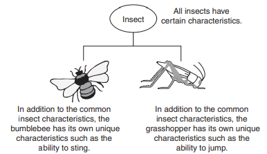

Inheritance allows a new class to extend an existing class. The new class inherits the members of the class it extends.

When one object is a specialized version of another object, there is an “is a” relationship between them. For example, a grasshopper is an insect. Here are a few other examples of the “is a” relationship:

• A car is a vehicle.

• A flower is a plant.

• A rectangle is a shape.

• A football player is an athlete

## Subclass & Superclass

Inheritance involves a superclass and a subclass. The superclass is the general class and the subclass is the specialized class. You can think of the subclass as an extended version of the superclass. The subclass inherits attributes and methods from the superclass without any of them having to be rewritten.

Superclasses are also called base classes, and subclasses are also called derived classes

#### Done For the Theory Let's see Examples

Suppose we are developing a program that a car dealership can use to manage its inventory of used cars The dealership’s inventory includes three types of automobiles: cars, pickup trucks and sport-utility vehicles (SUVs). . Regardless of the type, the dealership keeps the following data about each automobile:

• Make

• Year model

• Mileage

• Price

## Inheritance is better with UML Diagrams

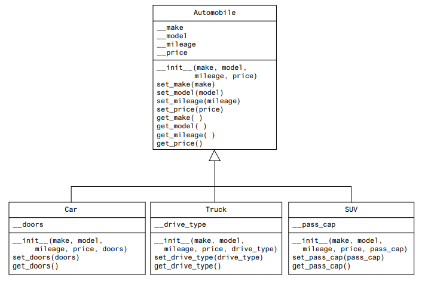

```python
# The Automobile class holds general data
# about an automobile in inventory

class Automobile:
  #  The __init__method accepts arguments for the
  # make, model, mileage, and price. It initializes
  # the data attributes with these values

  def __init__(self, manufacturer, model, mileage, price):
    self.__manufacturer = manufacturer
    self.__model = model
    self.__mileage = mileage
    self.__price = price

  # The following methods are the mutators for the
  # class's data attributes

  def set_manufacturer(self, manufacturer):
    self.__manufacturer = manufacturer

  def set_model(self, model):
    self.__model = model

  def set_mileage(self, mileage):
    self.__mileage = mileage

  def set_price(self, price):
    self.__price = price

  # The following methods are the accessors
  # for the class's data attributes

  def get_manufacturer(self):
    return self.__manufacturer

  def get_model(self):
    return self.__model

  def get_mileage(self):
    return self.__mileage

  def get_price(self):
    return self.__price
```

## Car subclass i.e. inherited from Superclass Automobile

```python
# The Car class represents a car. It is a subclass
# of the Automobile class.

class Car(Automobile):
  # The __init__ method accepts arguments for the
  # car's make, model, mileage, price, and doors.

  def __init__(self, manufacturer, model, mileage, price, doors):
    # Call the superclass's __init__ method and pass
    # the required arguments. Note that we also have
    # to pass self as an argument.
    # super().__init__(self, manufacturer, model, mileage, price)
    Automobile.__init__(self, manufacturer, model, mileage, price)

    # Initialize the __doors attribute.
    self.__doors = doors

  # The set_doors method is the mutator for the
  # __doors attribute.

  def set_doors(self, doors):
    self.__doors = doors

  # The get_doors method is the accessor for the
  # __doors attribute.
  def get_doors(self):
    return self.__doors
```

Let's create an object of Car

```python
# This program demonstrates the Car class.
def main():
  # Create an object from the Car class.
  # The car is a 2007 Audi with 12,500 miles, priced
  # at $21,500.00, and has 4 doors.
  used_car = Car('Audi', 2007, 12500, 21500.0, 4)

  # Display the car's data.
  print('Make:', used_car.get_manufacturer())
  print('Model:', used_car.get_model())
  print('Mileage:', used_car.get_mileage())
  print('Price:', used_car.get_price())
  print('Number of doors:', used_car.get_doors())

# Call the main function.
main()
```

```
Make: Audi
Model: 2007
Mileage: 12500
Price: 21500.0
Number of doors: 4
```

## Truck subclass i.e. inherited from Superclass Automobile

```python
# The Truck class represents a pickup truck. It is a
# subclass of the Automobile class.
class Truck(Automobile):
  # The __init__ method accepts arguments for the
  # Truck's make, model, mileage, price, and drive type.
  def __init__(self, manufacturer, model, mileage, price, drive_type):
    # Call the superclass's __init__ method and pass
    # the required arguments. Note that we also have
    # to pass self as an argument.
    Automobile.__init__(self, manufacturer, model, mileage, price)

    # Initialize the __drive_type attribute.
    self.__drive_type = drive_type

  # The set_drive_type method is the mutator for the
  # __drive_type attribute.
  def set_drive_type(self, drive_type):
    self.__drive = drive_type

  # The get_drive_type method is the accessor for the
  # __drive_type attribute.

  def get_drive_type(self):
    return self.__drive_type
```

## SUV subclass i.e. inherited from Superclass Automobile

```python
# The SUV class represents a sport utility vehicle. It
# is a subclass of the Automobile class.

class SUV(Automobile):
  # The __init__ method accepts arguments for the
  # SUV's make, model, mileage, price, and passenger
  # capacity.

  def __init__(self, manufacturer, model, mileage, price, pass_cap):
    # Call the superclass's __init__ method and pass
    # the required arguments. Note that we also have
    # to pass self as an argument.
    Automobile.__init__(self, manufacturer, model, mileage, price)

    # Initialize the __pass_cap attribute.
    self.__pass_cap = pass_cap

  # The set_pass_cap method is the mutator for the
  # __pass_cap attribute.

  def set_pass_cap(self, pass_cap):
    self.__pass_cap = pass_cap

  # The get_pass_cap method is the accessor for the
  # __pass_cap attribute.
  def get_pass_cap(self):
    return self.__pass_cap
```

#### Let's see all of it at once

```python
# This program creates a Car object, a Truck object,
# and an SUV object.

def main():
  # Create a Car object for a used 2001 BMW
  # with 70,000 miles, priced at $15,000, with
  # 4 doors.
  car = Car('BMW', 2001, 70000, 15000.0, 4)

  # Create a Truck object for a used 2002
  # Toyota pickup with 40,000 miles, priced
  # at $12,000, with 4-wheel drive.
  truck = Truck('Toyota', 2002, 40000, 12000.0, '4WD')

  # Create an SUV object for a used 2000
  # Volvo with 30,000 miles, priced
  # at $18,500, with 5 passenger capacity.
  suv = SUV('Volvo', 2000, 30000, 18500.0, 5)

  print('USED CAR INVENTORY')
  print('===================')

  # Display the car's data.
  print('The following car is in inventory:')
  print('Manufacturer:', car.get_manufacturer())
  print('Model:', car.get_model())
  print('Mileage:', car.get_mileage())
  print('Price:', car.get_price())
  print('Number of doors:', car.get_doors())
  print()

  # Display the truck's data.
  print('The following pickup truck is in inventory.')
  print('Manufacturer:', truck.get_manufacturer())
  print('Model:', truck.get_model())
  print('Mileage:', truck.get_mileage())
  print('Price:', truck.get_price())
  print('Drive type:', truck.get_drive_type())
  print()

  # Display the SUV's data.
  print('The following SUV is in inventory.')
  print('Manufacturer:', suv.get_manufacturer())
  print('Model:', suv.get_model())
  print('Mileage:', suv.get_mileage())
  print('Price:', suv.get_price())
  print('Passenger Capacity:', suv.get_pass_cap())


# Call the main function.
main()
```

```
USED CAR INVENTORY
===================
The following car is in inventory:
Manufacturer: BMW
Model: 2001
Mileage: 70000
Price: 15000.0
Number of doors: 4

The following pickup truck is in inventory.
Manufacturer: Toyota
Model: 2002
Mileage: 40000
Price: 12000.0
Drive type: 4WD

The following SUV is in inventory.
Manufacturer: Volvo
Model: 2000
Mileage: 30000
Price: 18500.0
Passenger Capacity: 5
```

## Access Modifiers During Inheritance

[figure not shown]

**Base Class**

```python
class Automobile:

  def __init__(self,make,mileage,price):
    self.make = make #public member
    self._mileage = mileage #protected member
    self.__price = price  #private member


  # The following methods are the mutators
  # for the class's data attributes

  def set_manufacturer(self, make):
    self.make = make

  def set_mileage(self, mileage):
    self._mileage = mileage

  def set_price(self, price):
    self.__price = price

  # The following methods are the accessors
  # for the class's data attributes

  def get_make(self):
    return self.make

  def get_mileage(self):
    return self._mileage

  def get_price(self):
    return self.__price
```

**Derived Class**

```python
# The Car class represents a car. It is a subclass
# of the Automobile class.

class Car(Automobile):
  # The __init__ method accepts arguments for the
  # car's make,  mileage, price, and doors.

  def __init__(self, make, model, mileage, price):
    # Call the superclass's __init__ method and pass
    # the required arguments. Note that we also have
    # to pass self as an argument.
    # super().__init__(self, manufacturer, model, mileage, price)
    Automobile.__init__(self, make, mileage, price)

    # Initialize the __doors attribute.
    self.model = model


#Method to show access of private member in derived class
  # def show_price(self):
  #   return self.__price

#Method to show access of protected member in derived class
  # def get_mileage(self):
  #   return self._mileage

  def set_model(self, model):
    self.__model = model


  def get_model(self):
    return self.__model
```

```python
auto = Automobile("Suzuki",19,1000000)
car = Car("Suzuki","Swift Dzire",19,1000000)
```

```python
#car.get_mileage()
```

[output not shown]

```python
#car.show_price()
```

[output not shown]

**Access Modifier for Public Member**

```python
print(auto.make) #from base class object
print(auto.get_make())  # from base class
print(car.make) #from derived class object
```

[output not shown]

**Access Modifier for Protected Member**

```python
print(auto.mileage) #from base class object
print(auto.get_mileage())  # from base class
print(car.mileage) #from derived class object
```

[output not shown]

**Access Modifier for Private Member**

```python
#print(auto.price) #from base class object
print(auto.get_price())  # from base class
#print(car.price) #from derived class object
```

[output not shown]

## Exception Handling

An exception is an error that occurs while a program is running, causing the program to abruptly halt. You can use the try/except statement to gracefully handle exceptions.

### Exception While Division

```python
0# This program divides a number by another number.
def main():
  # Get two numbers.
  num1 = int(input('Enter a number: '))
  num2 = int(input('Enter another number: '))

  # Divide num1 by num2 and display the result.
  result = num1 / num2
  print(num1, 'divided by', num2, 'is', result)

# Call the main function.
main()
```

```
Enter a number: 7
Enter another number: 0
```

```
---------------------------------------------------------------------------
ZeroDivisionError                         Traceback (most recent call last)
<ipython-input-50-a9019646d6f8> in <module>
     10
     11 # Call the main function.
---> 12 main()

<ipython-input-50-a9019646d6f8> in main()
      6
      7   # Divide num1 by num2 and display the result.
----> 8   result = num1 / num2
      9   print(num1, 'divided by', num2, 'is', result)
     10

ZeroDivisionError: division by zero
```

How do we solve divide by 0 here?

```python
# This program divides a number by another number.
def main():
  # Get two numbers.
  num1 = int(input('Enter a number: '))
  num2 = int(input('Enter another number: '))

  # Divide num1 by num2 and display the result.
  if num2 != 0:
    result = num1 / num2
    print(num1, 'divided by', num2, 'is', result)
  else:
    print('Can not divide by zero')

# Call the main function.
main()
```

```
Enter a number: 21
Enter another number: 0
Can not divide by zero
```

Calculating the Gross Pay of an employee

if we give hours/gross pay as a string "we get error"

```python
# This program calculates gross pay.

def main():
  # Get the number of hours worked.
  hours = int(input('How many hours did you work? '))

  # Get the hourly pay rate.
  pay_rate = float(input('Enter your hourly pay rate: '))

  # Calculate the gross pay.
  gross_pay = str(hours * pay_rate)

  # Display the gross pay.
  print('Gross pay: $', format(gross_pay, ',.2f'), sep='')

# Call the main function.
main()
```

```
How many hours did you work? 20
Enter your hourly pay rate: 2
```

```
---------------------------------------------------------------------------
ValueError                                Traceback (most recent call last)
<ipython-input-30-3f6066247972> in <module>
     15
     16 # Call the main function.
---> 17 main()

<ipython-input-30-3f6066247972> in main()
     12
     13   # Display the gross pay.
---> 14   print('Gross pay: $', format(gross_pay, ',.2f'), sep='')
     15
     16 # Call the main function.

ValueError: Unknown format code 'f' for object of type 'str'
```

Like most modern programming languages, Python allows you to write code that responds to exceptions when they are raised, and prevents the program from abruptly crashing. Such code is called an exception handler and is written with the try/except statement.

```python
try:
  statement_1
  statement_2
  etc..

except ExceptionName:
  statement_1
  statement_2
  etc..
```

When the try/except statement executes, the statements in the try suite begin to execute. The following describes what happens next:

1. If a statement in the try suite raises an exception that is specified by the ExceptionName in an except clause, then the handler that immediately follows the except clause executes. Then, the program resumes execution with the statement immediately following the try/except statement
2. If a statement in the try suite raises an exception that is not specified by the ExceptionName in an except clause, then the program will halt with a traceback error message.
3. If the statements in the try suite execute without raising an exception, then any except clauses and handlers in the statement are skipped, and the program resumes execution with the statement immediately following the try/except statement.

```python
# This program divides a number by another number.
def main():
  # Get two numbers.
  num1 = int(input('Enter a number: '))
  num2 = int(input('Enter another number: '))

  try:
    result = num1 / num2
    print(num1, 'divided by', num2, 'is', result)
  except ZeroDivisionError:
    print('Can not divide by zero')

# Call the main function.
main()
```

```
Enter a number: 5
Enter another number: 0
Can not divide by zero
```

```python
# This program calculates gross pay.

def main():
  try:
    # Get the number of hours worked.
    hours = int(input('How many hours did you work? '))

    # Get the hourly pay rate.
    pay_rate = float(input('Enter your hourly pay rate: '))

    # Calculate the gross pay.
    gross_pay = hours * pay_rate

    # Display the gross pay.
    print('Gross pay: $', format(gross_pay, ',.2f'), sep='')
  except ValueError:
      print('ERROR: Hours worked and hourly pay rate must be valid numbers.')

    # Call the main function

main()
```

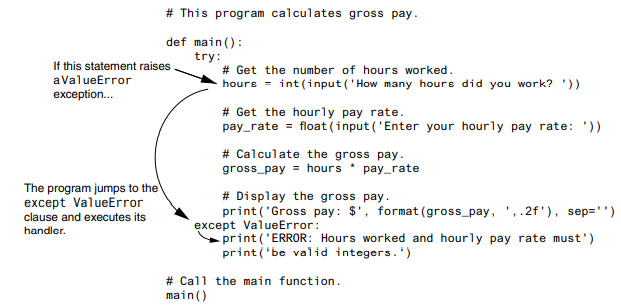

### Exception while reading a file

```python
# This program displays the contents
# of a file.
def main():
  # Get the name of a file.
  filename = input('Enter a filename: ')

  # Open the file.
  infile = open(filename, 'r')

  # Read the file's contents.
  contents = infile.read()

  # Display the file's contents.
  print(contents)

  # Close the file.
  infile.close()

# Call the main function.
main()
```

```
Enter a filename: rajendra
```

```
---------------------------------------------------------------------------
FileNotFoundError                         Traceback (most recent call last)
<ipython-input-1-b0048f6074cf> in <module>
     18
     19 # Call the main function.
---> 20 main()

<ipython-input-1-b0048f6074cf> in main()
      6
      7   # Open the file.
----> 8   infile = open(filename, 'r')
      9
     10   # Read the file's contents.

FileNotFoundError: [Errno 2] No such file or directory: 'rajendra'
```

Handle the exception using Try/Catch

```python
# This program displays the contents
# of a file.
def main():
  # Get the name of a file.
  filename = input('Enter a filename: ')

  try:
    # Open the file.
    infile = open(filename, 'r')

    # Read the file's contents.
    contents = infile.read()

    # Display the file's contents.
    print(contents)

    # Close the file.
    infile.close()
  except IOError:
    print('An error occurred trying to read the file', filename)

# Call the main function.
main()
```

```
Enter a filename: rajenra
An error occurred trying to read the file rajenra
```